# Central Limit Theorem Simulation for Exponential Distribution

Wei Lin

March 25, 2017

# Part 1

## Overview

We are going to verify the the central limit theorem by simulating a number of exponential distributed random variables.

## Simulations

```r
random_exp <- sapply(1:1000, function(x) rexp(40, 0.2))
```

## Sample Mean vs Theoretical Mean

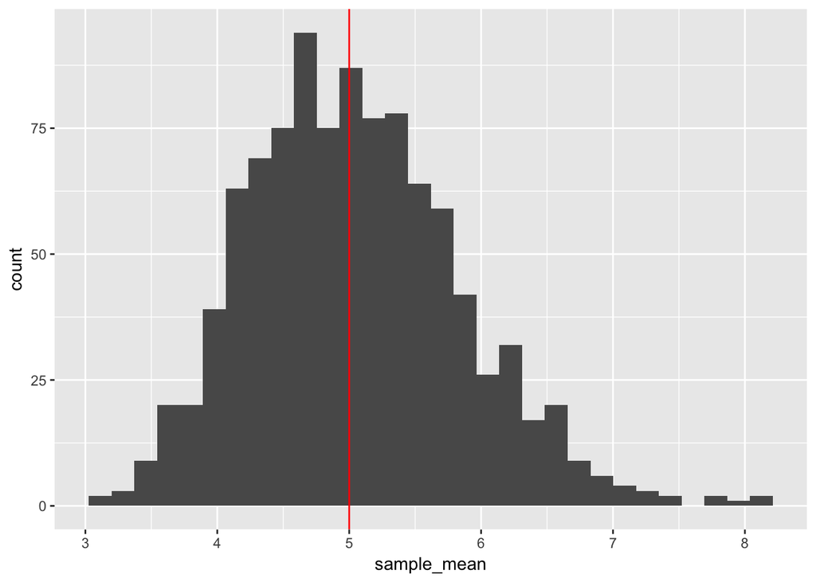

```r
library(ggplot2)
sample_mean <- apply(random_exp, 2, mean)
ggplot() + geom_histogram(aes(x = sample_mean)) +
    geom_vline(aes(xintercept = 1 / 0.2),col =
                   'red')
```

## Sample Variance vs Theoretical Variance

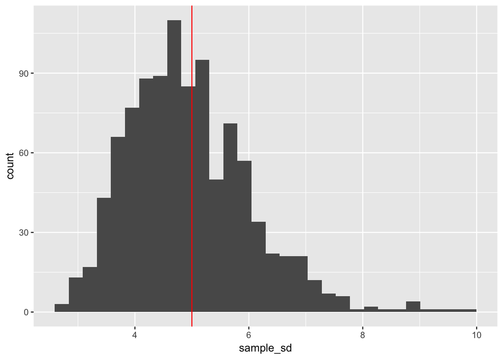

```r
sample_sd <- apply(random_exp, 2, sd)
ggplot() + geom_histogram(aes(x = sample_sd)) +
    geom_vline(aes(xintercept = 1 / 0.2),col =
                   'red')
```

## Distribution

Distribution of 1000 random exponentials are compared with 1000 of averages of 40 random exponentials

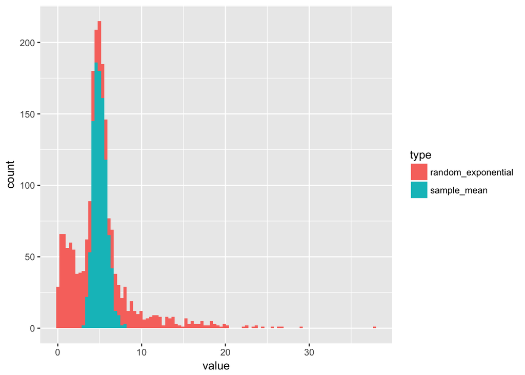

```r
library(tidyr)
compare <- data.frame(
    random_exponential =  rexp(1000, 0.2),
    sample_mean = apply(random_exp, 2, mean))
compare <- compare %>% gather(type, value)


ggplot(compare) + geom_histogram(
    aes(x = value, fill = type),bins = 100)
```

# Part 2

## Load Data and Summary

```r
library(datasets)
dim(ToothGrowth)
```

```
## [1] 60  3
```

```r
head(ToothGrowth)
```

```
##    len supp dose
## 1  4.2   VC  0.5
## 2 11.5   VC  0.5
## 3  7.3   VC  0.5
## 4  5.8   VC  0.5
## 5  6.4   VC  0.5
## 6 10.0   VC  0.5
```

```r
summary(ToothGrowth)
```

```
##       len        supp         dose
##  Min.   : 4.20   OJ:30   Min.   :0.500
##  1st Qu.:13.07   VC:30   1st Qu.:0.500
##  Median :19.25           Median :1.000
##  Mean   :18.81           Mean   :1.167
##  3rd Qu.:25.27           3rd Qu.:2.000
##  Max.   :33.90           Max.   :2.000
```

```r
str(ToothGrowth)
```

```
## 'data.frame':    60 obs. of  3 variables:
##  $ len : num  4.2 11.5 7.3 5.8 6.4 10 11.2 11.2 5.2 7 ...
##  $ supp: Factor w/ 2 levels "OJ","VC": 2 2 2 2 2 2 2 2 2 2 ...
##  $ dose: num  0.5 0.5 0.5 0.5 0.5 0.5 0.5 0.5 0.5 0.5 ...
```

## Test

For dose 0.5, we compare the tooth growth by supp using t test where the null hypothesis is that the tooth growth means of the two supp types is equal to zero

```r
t.test(len ~ supp, ToothGrowth,subset = ToothGrowth$dose == 0.5)
```

```
##
##  Welch Two Sample t-test
##
## data:  len by supp
## t = 3.1697, df = 14.969, p-value = 0.006359
## alternative hypothesis: true difference in means is not equal to 0
## 95 percent confidence interval:
##  1.719057 8.780943
## sample estimates:
## mean in group OJ mean in group VC
##            13.23             7.98
```

Given low p-value (less than 0.05), we reject the null hypothesis and claim that tooth grow faster under OJ than VC when does is 0.5

Perform the same test for dose 1

```r
t.test(len ~ supp, ToothGrowth,subset = ToothGrowth$dose == 1)
```

```
##
##  Welch Two Sample t-test
##
## data:  len by supp
## t = 4.0328, df = 15.358, p-value = 0.001038
## alternative hypothesis: true difference in means is not equal to 0
## 95 percent confidence interval:
##  2.802148 9.057852
## sample estimates:
## mean in group OJ mean in group VC
##            22.70            16.77
```

Given low p-value (less than 0.05), we reject the null hypothesis and claim that tooth grow faster under OJ than VC when does is 1

Perform the same test for dose 2

```r
t.test(len ~ supp, ToothGrowth,subset = ToothGrowth$dose == 2)
```

```
##
##  Welch Two Sample t-test
##
## data:  len by supp
## t = -0.046136, df = 14.04, p-value = 0.9639
## alternative hypothesis: true difference in means is not equal to 0
## 95 percent confidence interval:
##  -3.79807  3.63807
## sample estimates:
## mean in group OJ mean in group VC
##            26.06            26.14
```

Given high p-value (higher than 0.05), we cannot reject the null hypothesis and claim that speed of tooth grow is the same under OJ and VC when does is 2

## Conclusion

The OJ makes tooth growth faster than CV when dose is low. However, the benefit diminishes when dose is high.